# Amazon Sales Analysis

## Introduction

In the expansive Amazon marketplace, the volume of produce sales and customer ratings serve as key measures of product success and consumer satisfaction. This report explores the critical question:

-> How do customer ratings differ among Amazon’s product categories, and is there a correlation between these ratings and sales volumes?

Our motivation is driven by the need to comprehend how ratings affect customer purchasing behaviors and the goal of this research is to gain a better understanding of the ways in which certain product qualities, such as ratings, impact consumer choices and may even have an impact on wider market trends.

We propose that various elements, notably pricing and discount tactics, significantly impact customer purchasing decisions and reviews across different product categories. This hypothesis forms the foundation of our analysis: Customer satisfaction on Amazon is shaped by a complex array of factors that differ among categories, offering deep insights into online consumer behavior.

## Background

- **Key Variables:**
  - product_id: Unique identifier for each product.
  - product_name: Name of the product.
  - category: Classification of the product within Amazon’s hierarchy.
  - discounted_price: Product’s discounted and original prices.
  - actual_price: Product’s original price
  - discount_percentage: The percentage reduction from the original price.
  - rating: The average user rating for the product.
  - rating_count: The number of ratings a product has received.
  - review_content: Text content of the user review.

**Citation:** Karkavelraja J. Januart, 2023. “Amazon Sales Dataset”. Kaggle. https://www.kaggle.com/datasets/karkavelrajaj/amazon-sales-dataset/data

> This capacity to gain focused insights into consumer behaviour and sales dynamics through a granular emphasis on key variables is essential for optimising product offers and marketing tactics in highly competitive digital marketplaces and our focus is to examine and assess the sales and rating performance across various product categories, along with investigating the correlation between customer ratings and sales volume for all products.

## Analysis

> We arrange and examine the data in our research, paying particular attention to how sales are distributed throughout different Amazon product categories. Assuming that greater rating counts correspond to higher customer demand and sales, we use rating counts as a stand-in for sales volume. The ‘Computers & Accessories’, ‘Electronics’, and ‘Home & Kitchen’ product categories are highlighted in this bar graph, it also shows how customer preferences change within each category. The categories with the greatest rating counts are assumed to be the most popular among consumers, probably because of their technological significance and fundamental usefulness. Important business decisions concerning product offerings are guided by this visualisation, which also helps in recognising consumer trends.

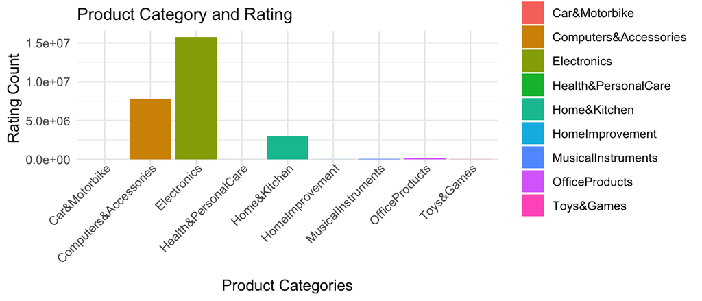

> Based on the first graph, it seems that the categories Computers & Accessories, Electronics, and Home & Kitchen exhibit the highest rating counts, indicating higher sales volume. Now, by concentrating on the product categories with lower rating counts and omitting the top three, this next bar graph enhances our study. Through dissecting these categories, we can gain a deeper understanding of less common product types and specialised markets. This study is essential for determining possible development regions or industries that could gain from more intensive marketing campaigns. These less common categories may provide insights into unexplored markets or chances for product diversification.

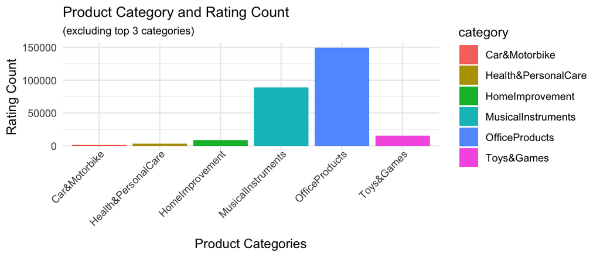

A simpler way to show how sales volume is spread among different product categories is by illustrating the percentage of total rating counts contributed by each category. Therefore, The percentage distribution of all rating counts for each product category is shown in this table.

```
## # A tibble: 9 × 2
##   category              percentage
##   <chr>                      <dbl>
## 1 Car&Motorbike          0.0000418
## 2 Computers&Accessories  0.289
## 3 Electronics            0.590
## 4 Health&PersonalCare    0.000137
## 5 Home&Kitchen           0.112
## 6 HomeImprovement        0.000320
## 7 MusicalInstruments     0.00332
## 8 OfficeProducts         0.00559
## 9 Toys&Games             0.000593
```

In general, there are notable differences in sales volume across various product categories. Notably, `Computers & Accessories`, `Electronics`, and `Home & Kitchen` collectively represent a significant portion of the total rating count or sales volume for all Amazon products.

> Afterward, we’ll analyze customer ratings for each product category to evaluate overall consumer satisfaction levels. We’ll use the mean rating as a measure of the rating for each product category and visualize the data accordingly.

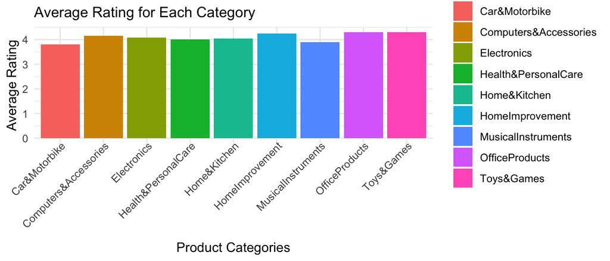

The average rating graph for many product categories shows a generally stable degree of consumer satisfaction. Notably, categories like “Computers & Accessories” and “Electronics,” which have a higher volume of reviews, demonstrate that a bigger volume of ratings does not always equate to a lower perceived quality. This constancy shows that a variety of product lines are meeting consumer expectations.

> We delved deeper to examine the rating distribution for each product category using box plots.

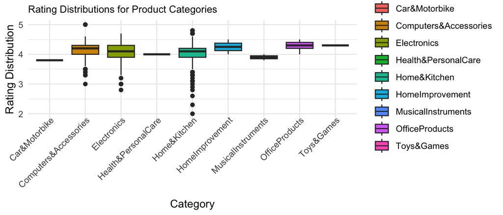

Here we observe significant variation in the distribution of `Rating` across different product categories. Some categories display wide spreads in rating distribution, while others have narrower ones. When juxtaposing this graph with the bar plots depicting `Product Category` against `Rating Count`, we observed that categories with higher sales volume (rating count) tend to exhibit broader distributions. This correlation is logical, as larger databases offer a more comprehensive representation of the data’s characteristics.

> Next, we’re investigating the potential correlation between customer ratings and sales volume across all product categories on Amazon. Due to the absence of actual sales data, we’ll use the number of ratings as a approximate measure to estimate sales volume. The scatter plot will depict product ratings against the number of ratings, allowing us to visually ascertain whether products with higher ratings also tend to have higher sales. This straightforward yet informative analysis aims to uncover any trends indicating that customer ratings could impact sales.

```
##    Min. 1st Qu.  Median    Mean 3rd Qu.    Max.    NA's
##   2.000   4.000   4.100   4.097   4.300   5.000       1
```

```
##    Min. 1st Qu.  Median    Mean 3rd Qu.    Max.    NA's
##       2    1186    5179   18296   17336  426973       2
```

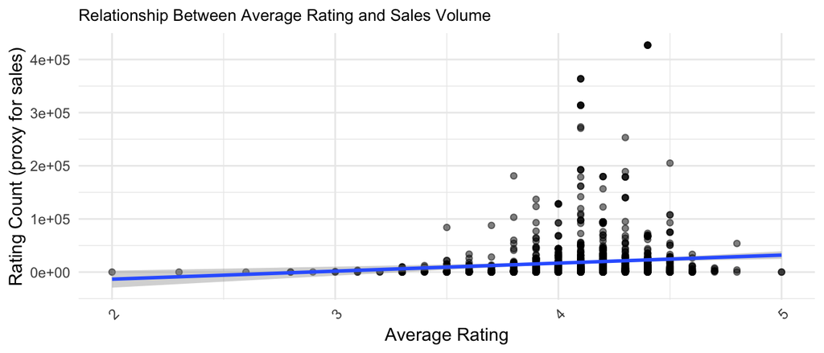

In the following graph, it uses a logarithmic scale which makes the relationship between product ratings and sales volume more clear, especially for products that have very high or low rating counts. With a few exceptions, the log transformation helps control the large range of values, enhancing the trend and emphasising that, on the whole, higher-rated products outperform lower-rated ones in terms of sales.

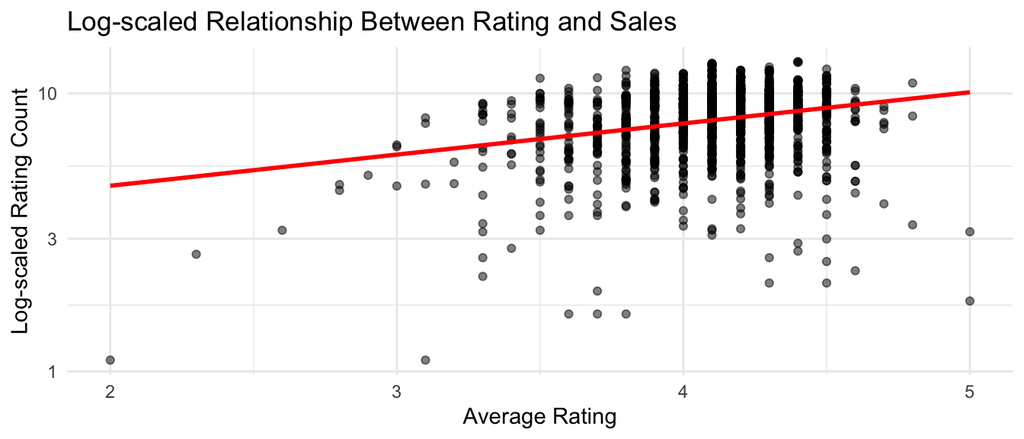

#### Hypothesis Test

$$H_0: \theta = 0 \\
H_a: \theta \neq 0$$

We test the null that our slope parameter $\theta$ is 0, suggesting no correlation between `Average Product Rating` and `Number of Ratings`, against the alternative that there is a correlation.

#### Test Statistic

$$T = \frac{\hat{\theta} - 0}{s_{\hat{\theta}}}$$

```
##
##  Pearson's product-moment correlation
##
## data:  amazon$rating and amazon$rating_count
## t = 3.927, df = 1460, p-value = 9.004e-05
## alternative hypothesis: true correlation is not equal to 0
## 95 percent confidence interval:
##  0.05123617 0.15270166
## sample estimates:
##       cor
## 0.1022348
```

**Hypothesis:** In our analysis, a value of 0.1022348 suggests a positive yet weak correlation. This implies that as the average rating rises, the number of ratings (our sales proxy) also tends to increase, albeit with limited strength.

**P-value:** With a p-value below the conventional threshold of 0.05, we can dismiss the null hypothesis asserting no correlation between the two variables. Thus, there is statistically significant evidence supporting the existence of a relationship between average rating and the number of ratings.

**Confidence Interval:** The confidence interval for the correlation coefficient spans from 0.05123617 to 0.15270166. This interval provides an estimation of the possible values for the true correlation coefficient, with 95% confidence. As the interval excludes 0, it reinforces the conclusion of a positive correlation.

#### Interpretation

The Amazon data reveals a minor positive association between `Product Ratings` and the `Number of Ratings`, indicated by a Pearson correlation coefficient of 0.10. Despite its statistical significance, the correlation suggests a weak relationship. This implies that while improved ratings might marginally boost the number of ratings—our proxy for estimating sales—they do not independently ensure higher sales. Hence, other factors such as marketing strategies and product visibility likely exert considerable influence on sales outcomes.

[figure not shown]

## Discussion

#### Potential Shortcomings

The main drawback of our analysis stems from its dependence solely on Amazon ratings to gauge customer satisfaction and engagement. This reliance introduces subjectivity, as ratings can be influenced by various factors beyond product quality, leading to potential bias. For example, customers who are more inclined to leave reviews may hold extreme opinions, thereby affecting the average rating towards either positive or negative extremes. Furthermore, our analysis overlooks other indicators such as written customer reviews, return rates, and repeat purchases, which could offer a more comprehensive understanding of customer satisfaction. Furthermore, the dataset’s restriction to Amazon might have missed more general e-commerce trends or customer preferences, which might differ greatly on other platforms or in other geographic areas.

#### Future Directions

- New Questions: Future research could explore the sales volume of the same product both on Amazon and in-store. By comparing the sales numbers and prices, sellers may discern whether e-commerce is more competitive compared to physical stores.
- Different Methods: In the future, it is possible to implement advanced machine learning algorithms to predict sales trends based on various product attributes and customer behaviors. Furthermore, employing text mining techniques on customer reviews and sentiment analysis could offer deeper insights into consumer preferences and product sentiment on Amazon.
- New Data: This might include collecting data on customer demographics, such as age, gender, and location, to better understand target markets and tailor marketing strategies accordingly. Moreover, acquiring data on competitor pricing and promotional strategies would offer valuable insights to inform pricing decisions and enhance competitiveness on the platform.
- Investigating longitudinal data may also highlight changes in consumer trends over time, offering insights into the lifetime of consumer loyalty and product popularity.